# Modeling and prediction for movies

## Setup

### Load packages

```r
library(ggplot2)
library(dplyr)
library(statsr)
```

### Load data

```r
load("movies.Rdata")
```

## Part 1: Data

The data set is comprised of 651 randomly sampled movies produced and released before 2016.

## Part 2: Research question

What is the parsimonious model for predicting how much audiences like movies (variable: audience_score) from numerous variables about the movies?

In general, many reasons would impact audience’s feeling about a movie. In this study, I will focus on 8 variables which are of high interest for me. The 8 variables I will discuss are the genre of movie (variable_1: genre), the MPAA rating of the movie (variable_2: mpaa_rating), the runtime of movie (variable_3: runtime), critics score (variable_4: critics_score), whether or not the movie was nominated for best picture Oscar (variable_5: best_pic_nom), whether or not one of the main actors or actress in the movie won an Oscar (variable_6: best_actor_win, variable_7: best_actress_win), and whether or not the direct or of the movie even won an Oscar (Variable_8: best_dir_win).

## Part 3: Exploratory data analysis

#### Get familar and clear the 9 variables (1 response variable, 8 explanatory variables)

I will remove the rows with missing values.

```r
#remove all rows with any missing values from the 9 variables
movies <- movies %>%
  filter(!is.na(audience_score), !is.na(genre), !is.na(mpaa_rating), !is.na(runtime),
         !is.na(critics_score), !is.na(best_pic_nom), !is.na(best_actor_win), !is.na(best_actress_win), !is.na(best_dir_win))
```

```r
#get familar with the response variable: audience_score
summary(movies$audience_score)
```

```
##    Min. 1st Qu.  Median    Mean 3rd Qu.    Max.
##   11.00   46.00   65.00   62.35   80.00   97.00
```

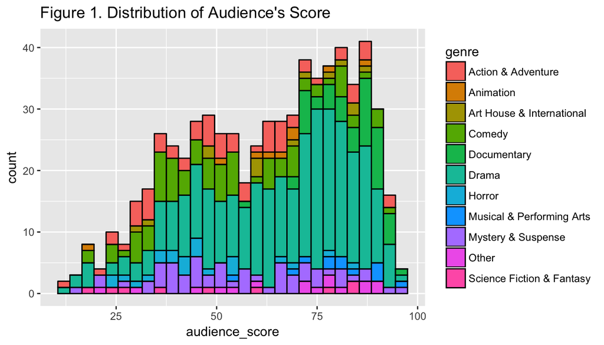

```r
#get familar with the relationships between the response variable and explanatory variables (genre,mpaa_rating)
ggplot(data=movies, aes(x=audience_score, fill=genre)) +
  geom_histogram(binwidth=3, colour="Black") +
  ggtitle("Figure 1. Distribution of Audience's Score")
```

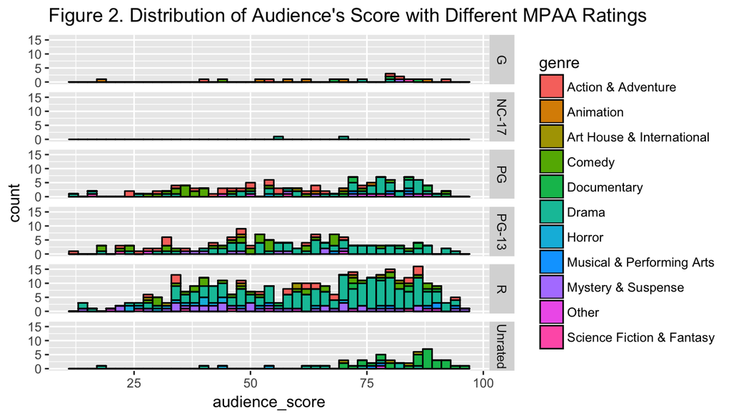

```r
ggplot(data=movies, aes(x=audience_score, fill=genre)) +
  geom_histogram(binwidth=2, colour="Black") +
  facet_grid(mpaa_rating ~.) +
  ggtitle("Figure 2. Distribution of Audience's Score with Different MPAA Ratings")
```

From Figure 1, the distribution of audience’ scores are a bit left skewed, however not too bad. In addition, we could see that most of the movies are drama.

From Figure 2, referring to the MPAA Ratings, most of the movies are identified as “R”. While the movies identified as “MC-17” are very rare.

Finally, since these 2 explanatory variables are categorical, I won’t check the linear relationships between each explanatory variable and the response variable.

### Simple linear regression one: runtime VS audience_score

```r
#get familar with the continuous explanatory variable runtime, and check for outliers, and clear the variable
summary(movies$runtime)
```

```
##    Min. 1st Qu.  Median    Mean 3rd Qu.    Max.
##    39.0    92.0   103.0   105.8   115.8   267.0
```

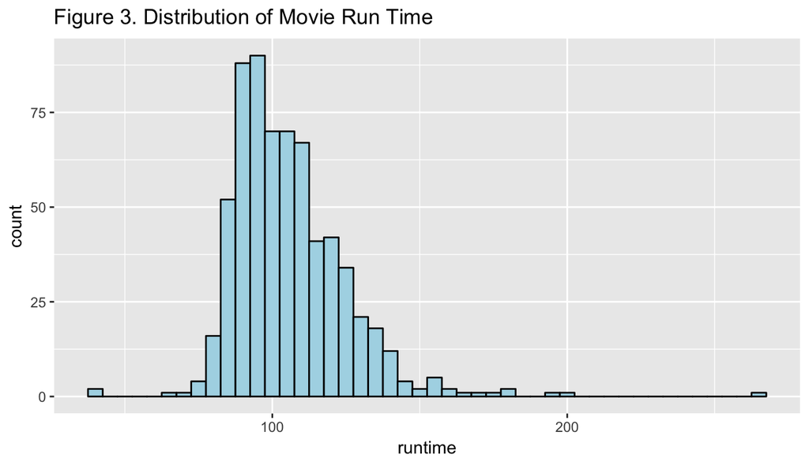

```r
ggplot(data=movies %>% filter(!is.na(runtime)), aes(x=runtime)) +
  geom_histogram(binwidth=5, fill="LightBlue", colour="Black") +
  ggtitle("Figure 3. Distribution of Movie Run Time")
```

From the Figure 3 above, the distribution of the movie runtime looks a bit right skewed, and with several extremes, but not bad.

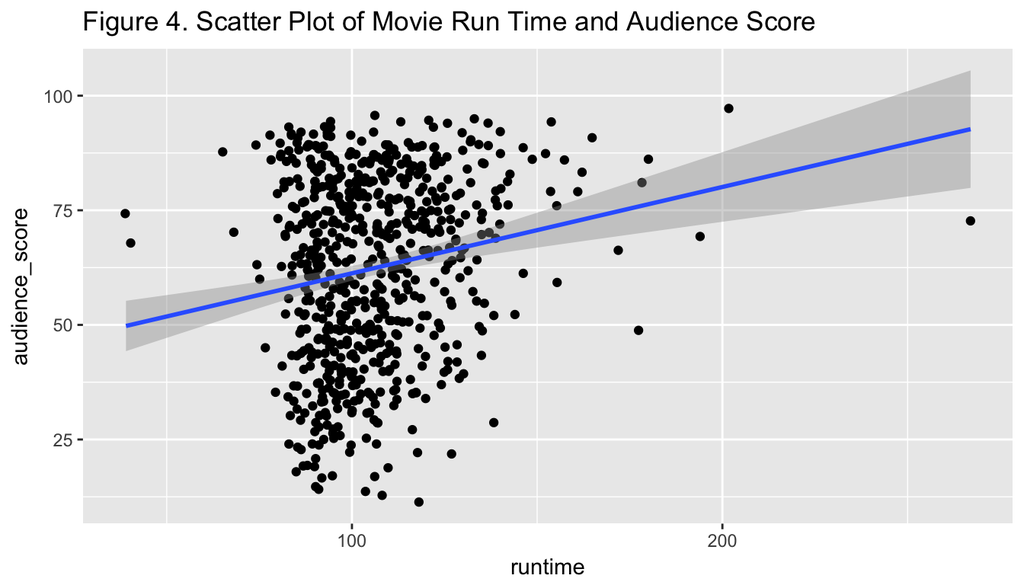

```r
#check whether the explanatory variable runtime is linearily related with the response variable
ggplot(data=movies, aes(x=runtime, y=audience_score)) +
  geom_jitter() +
  geom_smooth(method="lm") +
  ggtitle("Figure 4. Scatter Plot of Movie Run Time and Audience Score")
```

```r
movies %>%
  summarise(cor(runtime, audience_score))
```

```
## # A tibble: 1 x 1
##   `cor(runtime, audience_score)`
##                            <dbl>
## 1                          0.181
```

Both the scatter plot and correlation value R indicate that the explanatory variable runtime and response variable audience score are not strongly linearily related.

```r
#create the simple liner regression predicting audience_score from runtime
m1 <- lm(audience_score ~ runtime, data=movies)
summary(m1)
```

```
##
## Call:
## lm(formula = audience_score ~ runtime, data = movies)
##
## Residuals:
##     Min      1Q  Median      3Q     Max
## -53.641 -15.626   3.008  17.080  34.950
##
## Coefficients:
##             Estimate Std. Error t value Pr(>|t|)
## (Intercept)  42.4203     4.3256   9.807  < 2e-16 ***
## runtime       0.1883     0.0402   4.684 3.43e-06 ***
## ---
## Signif. codes:  0 '***' 0.001 '**' 0.01 '*' 0.05 '.' 0.1 ' ' 1
##
## Residual standard error: 19.92 on 648 degrees of freedom
## Multiple R-squared:  0.03275,    Adjusted R-squared:  0.03125
## F-statistic: 21.94 on 1 and 648 DF,  p-value: 3.431e-06
```

The Adjusted R-square value is 3%, which is very low, indicates a weak model.

### Simple linear regression two: critics_score VS audience_score

```r
#get familar with the continuous explanatory variable crtics_score
summary(movies$critics_score)
```

```
##    Min. 1st Qu.  Median    Mean 3rd Qu.    Max.
##    1.00   33.00   61.00   57.65   83.00  100.00
```

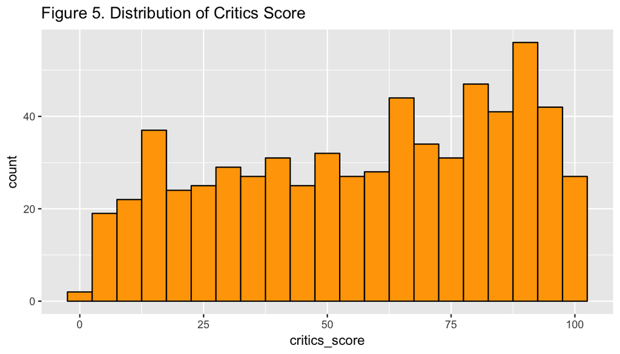

```r
ggplot(data=movies, aes(x=critics_score)) +
  geom_histogram(binwidth=5, fill="Orange", colour="Black") +
  ggtitle("Figure 5. Distribution of Critics Score")
```

From the Figure 5, the variable critics_score looks uniform, with no outliers.

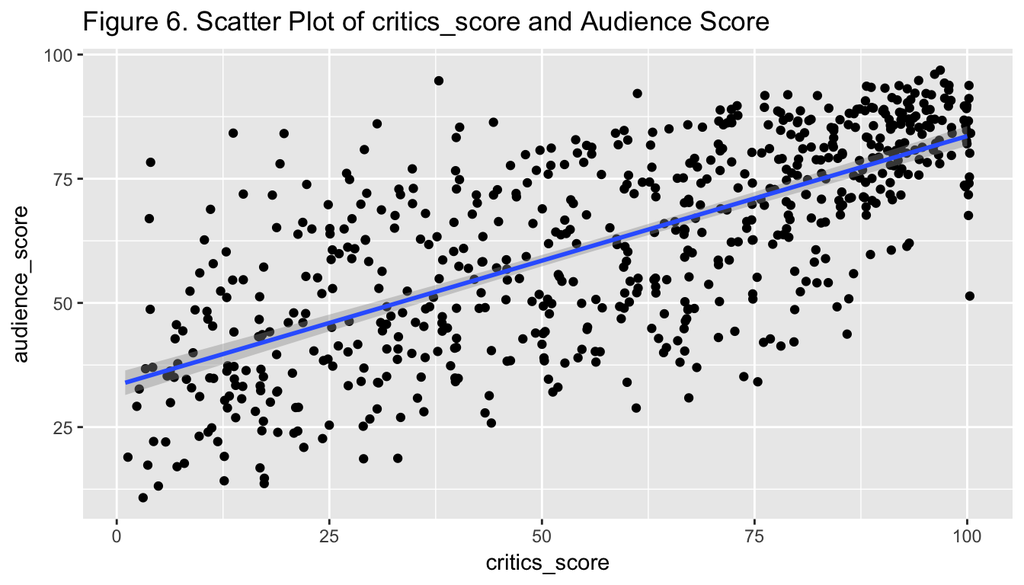

```r
#check whether the explanatory variable crtics_score is linearily related with the response variable
ggplot(data=movies, aes(x=critics_score, y=audience_score)) +
  geom_jitter() +
  geom_smooth(method="lm") +
  ggtitle("Figure 6. Scatter Plot of critics_score and Audience Score")
```

```r
movies %>%
  summarise(cor(critics_score, audience_score))
```

```
## # A tibble: 1 x 1
##   `cor(critics_score, audience_score)`
##                                  <dbl>
## 1                                0.704
```

From Figure 6, as expected the relationship between critics score and audience score is quite strong. The blue line is the model. The shaded gray area around the line tells us the variability we might expect in our predictions. It looks ok. The correlation value R also indicates a quite strong linear relationship of 0.7.

```r
#create the simple liner regression predicting audience_score from critics_score
m2 <- lm(audience_score ~ critics_score, data=movies)
summary(m2)
```

```
##
## Call:
## lm(formula = audience_score ~ critics_score, data = movies)
##
## Residuals:
##     Min      1Q  Median      3Q     Max
## -37.047  -9.580   0.711  10.418  43.545
##
## Coefficients:
##               Estimate Std. Error t value Pr(>|t|)
## (Intercept)   33.43408    1.27665   26.19   <2e-16 ***
## critics_score  0.50150    0.01987   25.25   <2e-16 ***
## ---
## Signif. codes:  0 '***' 0.001 '**' 0.01 '*' 0.05 '.' 0.1 ' ' 1
##
## Residual standard error: 14.38 on 648 degrees of freedom
## Multiple R-squared:  0.4958, Adjusted R-squared:  0.4951
## F-statistic: 637.3 on 1 and 648 DF,  p-value: < 2.2e-16
```

The Adjusted R-square is 49.52%, looks good.

```r
#get familar with other 4 categorical variables, best_pic_nom, best_actor_win, best_actress_win, and best_dir_win
#1. best_pic_nom
movies %>%
  group_by(best_pic_nom) %>%
  summarise(count=n())
```

```
## # A tibble: 2 x 2
##   best_pic_nom count
##   <fct>        <int>
## 1 no             628
## 2 yes             22
```

```r
#2. best_actor_win
movies %>%
  group_by(best_actor_win) %>%
  summarise(count=n())
```

```
## # A tibble: 2 x 2
##   best_actor_win count
##   <fct>          <int>
## 1 no               557
## 2 yes               93
```

```r
#3. best_actress_win
movies %>%
  group_by(best_actress_win) %>%
  summarise(count=n())
```

```
## # A tibble: 2 x 2
##   best_actress_win count
##   <fct>            <int>
## 1 no                 578
## 2 yes                 72
```

```r
#4. best_dir_win
movies %>%
  group_by(best_dir_win) %>%
  summarise(count=n())
```

```
## # A tibble: 2 x 2
##   best_dir_win count
##   <fct>        <int>
## 1 no             607
## 2 yes             43
```